# 第1回 実験経済学とデータ記録

経済プログラミング特論II

第1回

実験経済学とデータ記録

結果を知る前の選択を、データとして残す

経済プログラミング特論II

第1回 — Topic01

実験経済学と美人投票

予想をデータとして残す

## 自分の得が、他の人の選び方で決まる

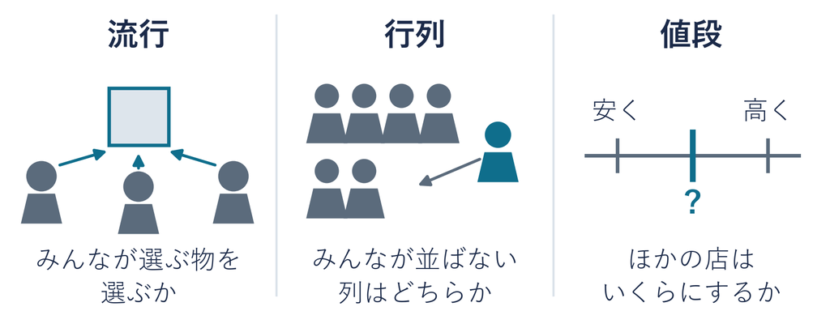

どれも自分ひとりでは答えが決まらない  
今日は、こうした場面を教室で作る

## 今日の道のり

1

美人投票

演習 1-1

美人投票に4回答える

2

公共財ゲーム

演習 1-2

公共財に2回答える

3

データの行き先

演習 1-3

1行メモを残す

今日は2つのゲームで、6回選ぶ  
結果を知る前の選択を、データとして残す

## 実験経済学

用語

人に実際に選んでもらい、  
その選択を記録して調べる方法を、実験経済学と呼ぶ

- **規則**：何を選び、どう勝ち負けが決まるかを先に決める
- **情報**：選ぶ前に何を知っているかを、全員でそろえる
- **記録**：選んだ数を、結果を知る前に残す

今日は、この教室が実験室になる

## 今日の約束

- **成績に関係しない**：どの数を選んでも、  
  勝っても負けても、評価は変わらない
- **匿名**：フォームに名前も学籍番号も書かない
- **出席は respon**：最初に respon で出席を送る。フォームとは別
- **教材になる**：今日の回答は、あとでこの授業で読むデータ

研究のための実験ではなく、データの読み方を体験するための教室実験

## フォームを開く：美人投票 R1

美人投票 R1（1回目）

manaba  
第1回のページから  
「美人投票 R1」のフォーム

開き方

1. manaba の第1回ページから、  
   フォームを開く
2. 受付前は「いまは受け付け  
   ていません」と出る（開き方  
   は合っている）
3. ルールを聞いてから、  
   読み込み直して答える

教室では、画面の QR から開いてもよい

## 動画で参加する人へ

1. manaba の第1回ページから、フォームを開いておく
2. 「R1：フォームの答え方」の枚で動画を止めて答える
3. 区分は「動画」を選ぶ。教室の勝ち負けには混ぜない
4. 答えて送ったら、再生に戻る

受付は10月11日（日）23:59まで  
動画の中で読む平均は、教室で集めた値

## 美人投票のルール

実験の規則

0〜100の整数をひとつ選ぶ。全員の平均の3分の2に、  
いちばん近い数を書いた人が勝ち

- **目標値**：全員の平均 × 2/3（同じ近さなら全員が勝ち）
- **平均に入る回答**：締め切りまでに届いた「教室」の回答  
  （自分の分も入る）
- **名前の由来**：ケインズが株の売り買いを、  
  皆が選ぶ顔を当てる新聞の懸賞にたとえた

## 目標値を数直線で見る

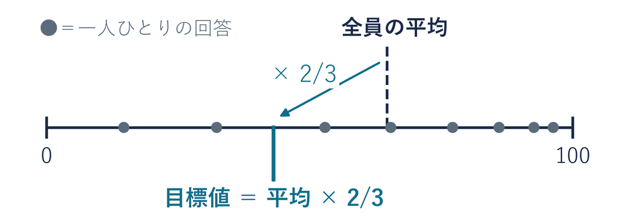

平均が決まると、  
目標値は0から平均までの3分の2の位置に決まる

## R1：フォームの答え方 — STEP は4つ

1. **区分**を選ぶ（教室／動画）
2. **確認の問い**に答える：「全員の平均が60なら、目標値はいくつ？」  
   （30／40／60／90 から選ぶ）
3. **数を1つ**書く：0〜100の整数
4. **送る前に**、自分の数をメモかスクショで残してから送信

相談せずに、ひとりで選ぶ  
動画で参加する人は、ここで止めて答える

## R1 を締め切る：見るのは平均と目標値だけ

- **先生が読む**：回答シートの件数と平均を読み、次の枠に打つ
- **その時点で残す**：読んだ件数と平均は、  
  あとから届いた回答で書き換えない
- **映さない**：分布と一人ずつの数は、あとで開けるまで封をしておく
- **確認の問い**：間違えた人の数も、平均に入れる

待つあいだの問い：次は上げる？下げる？（心の中で決めておく）

結果を知る前の R1 は、一度きりしか残せない

## デモ：平均から目標値を出す

数の話

目標値 ＝ 全員の平均 × 2/3（小数1桁）。  
公共財は平均の拠出をそのまま出す

- **何を見るか**：大きく出る数だけ。分布と一人ずつの数は入れない
- **図の意味**：上のタブで回を選ぶ。下の表に6回分の件数と平均が並ぶ
- **操作**：件数と平均を入れて「表示する」。  
  動画の人は動画で読む教室の平均を使う

ミッション 平均を打ち込み、目標値（平均×2/3）を読む

※ 次のスライドへ進むときは、デモの枠の外を一度クリックしてから ← → キーを押す

[interactive chart not shown]

## R2：集計情報を見た後の再選択

美人投票 R2（2回目）

manaba  
第1回のページから  
「美人投票 R2」のフォーム

答え方

1. 区分を選ぶ（教室／動画）
2. R1 の数を書く  
   （自己申告・空欄可）
3. 新しい数を、  
   0〜100の整数で書く
4. 送る前に、  
   メモかスクショで残す

話し合いはしない。締め切ったら、R2 の平均と目標値も同じ枠で見る

## R3：R2 の平均を見た再選択（美人投票）

美人投票 R3（3回目）

manaba  
第1回のページから  
「美人投票 R3」のフォーム

答え方

1. 区分を選ぶ（教室／動画）
2. R2 の数を書く  
   （自己申告・空欄可）
3. 新しい数を、  
   0〜100の整数で書く
4. 送る前に、  
   メモかスクショで残す

話し合いはしない。締め切ったら、R3 の平均と目標値も同じ枠で見る

## R4：R3 の平均を見た再選択（美人投票）

美人投票 R4（4回目）

manaba  
第1回のページから  
「美人投票 R4」のフォーム

答え方

1. 区分を選ぶ（教室／動画）
2. R3 の数を書く  
   （自己申告・空欄可）
3. 新しい数を、  
   0〜100の整数で書く
4. 送る前に、  
   メモかスクショで残す

話し合いはしない。締め切ったら、R4 の平均と目標値も同じ枠で見る

## 戦略的相互依存

用語

自分の得が、他の人がどう選ぶかで決まる状態を、  
戦略的相互依存と呼ぶ

- **美人投票では**：勝てる数は、全員の数で決まる
- **全員が同じ立場**：他の人も、他の人を読んで選ぶ
- **最初の三場面**：流行・行列・値段も同じ

教室の分布と一人ずつの数は、あとで開けて読む

## まとめ

- **実験経済学**：人に実際に選んでもらい、  
  選択を記録して調べる
- **美人投票**：0〜100の整数。目標値＝全員の平均 × 2/3
- **R1〜R4**：R1 は結果を知る前、  
  R2〜R4 は1つ前の平均と目標値を見た後の再選択
- **戦略的相互依存**：自分の得が、他の人の選び方で決まる

残した4つの回答は、あとで開けて読む

経済プログラミング特論II

第1回 — Topic02

公共財ゲーム

自分のためか、皆のためか

## 今日の道のり

1

美人投票

演習 1-1

美人投票に4回答える

2

公共財ゲーム

演習 1-2

公共財に2回答える

3

データの行き先

演習 1-3

1行メモを残す

美人投票の R1〜R4 は送り終えた  
次は、皆で出し合うゲームで2回選ぶ

## 共用品の費用は、誰が出す？

シェアハウスの共用品

洗剤もトイレットペーパーも  
誰かが買えば全員が使える

グループ課題

皆が手を動かせば良い  
発表になる  
自分が手を抜いても、  
発表はできあがる

出した人も出さなかった人も、同じように使える

## 公共財ゲームのルール

実験の規則

持ち点は20点。共同の箱に0〜20点の整数を入れる。  
箱の合計を1.6倍して、4人で等分する  
**目標：自分の受け取りを、できるだけ多くする**

- **公共財**：出さなかった人も使えるもの（共同の箱）
- **拠出**：箱に入れる点。入れなかった点は手元に残る
- **受け取り**：手元に残した点 ＋ 箱からの分け前  
  （箱の合計 × 1.6 ÷ 4）

## 共同の箱の流れ

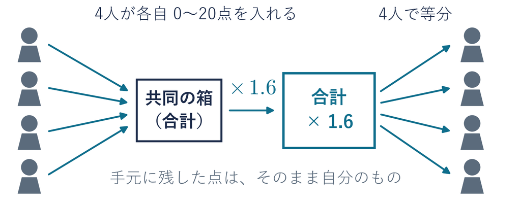

入れた点は1.6倍になり、入れなかった人にも  
同じだけ分けられる

## 選ぶ前に：組は授業のあとで作る

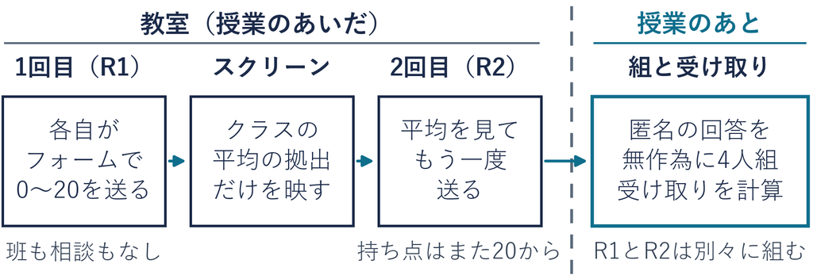

- **端数の人**：4で割り切れないとき、余った人は受け取りを計算しない  
  （その人数は明示する）。分布と平均には入れる
- **たとえば**：Wikipedia の寄付。寄付しなくても皆が読めるが、  
  誰が寄付したかは見えず、全体の様子だけが分かる

誰と組むかは、選ぶ時点では誰にも分からない

## 例題：受け取りを計算する

| 場面 | 箱の合計 | × 1.6 | 1人の分け前 | 受け取り |
| --- | --- | --- | --- | --- |
| 全員が0点 | 0 | 0 | 0 | 各自20 |
| 全員が20点 | 80 | 128 | 32 | 各自32 |
| 自分だけ20点 | 20 | 32 | 8 | 自分8・他の人28 |

受け取り＝手元に残した点＋分け前。自分だけ20点なら、  
手元0＋分け前8で8点

## 公共財 R1：フォームで答える

公共財 R1（1回目）

manaba  
第1回のページから  
「公共財 R1」のフォーム

答え方

1. 区分を選ぶ（教室／動画）
2. 確認の問い（下）に答える
3. 他の3人が何点入れるかを  
   考えて、自分の点（0〜20の  
   整数）を書く
4. 送る前に、  
   メモかスクショで残す

確認の問い：「自分だけ20点入れ、他の3人が0点なら、自分の受け取りはいくつ？」  
（0／8／20／28） 相談せずに選ぶ。動画の人はここで止める

## R1 を締め切る：見るのは平均の拠出だけ

- **先生が読む**：件数と平均の拠出を読み、枠の「公共財 R1」に打つ
- **その時点で残す**：読んだ件数と平均は、  
  あとから届いた回答で書き換えない
- **映さない**：一人ずつの拠出と4人組の受け取りは、あとで開ける

待つあいだの問い：次は増やす？減らす？（心の中で決めておく）

## 公共財 R2：集計情報を見た後の再選択

公共財 R2（2回目）

manaba  
第1回のページから  
「公共財 R2」のフォーム

答え方

1. 区分を選ぶ（教室／動画）
2. R1 の数を書く  
   （自己申告・空欄可）
3. 新しい拠出を、  
   0〜20の整数で書く  
   （持ち点はまた20から）
4. 送る前に、  
   メモかスクショで残す

話し合いはしない。締め切ったら、R2 の平均の拠出も同じ枠で見る

## 1点入れると、誰がどれだけ得をするか

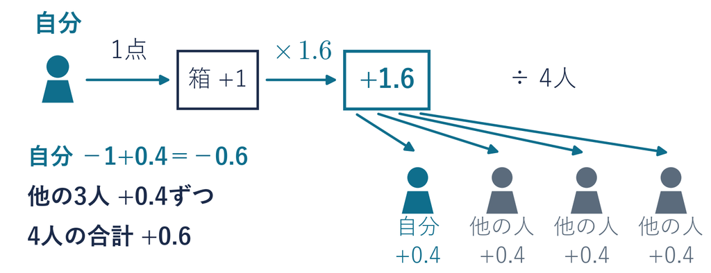

自分には −0.6、4人の合計には ＋0.6。  
一人ひとりの損得と、皆の損得が食い違う

## まとめ

- **公共財**：出さなかった人も同じように使えるもの
- **ルール**：持ち点20。箱の合計 × 1.6 を4人で等分
- **1点の行き先**：自分 −0.6  
  他の3人は ＋0.4 ずつ、4人の合計は ＋0.6
- **R2**：平均の拠出を見た後の再選択（持ち点は各回20）

教室の拠出がどうだったかは、あとで開けて読む

経済プログラミング特論II

第1回 — Topic03

教室実験とシミュレーション

今日のデータの行き先

## 今日の道のり

1

美人投票

演習 1-1

美人投票に4回答える

2

公共財ゲーム

演習 1-2

公共財に2回答える

3

データの行き先

演習 1-3

1行メモを残す

6つの回答は送り終えた  
最後に、このデータをどう読むかを確かめる

## 今日集めた6つの回答

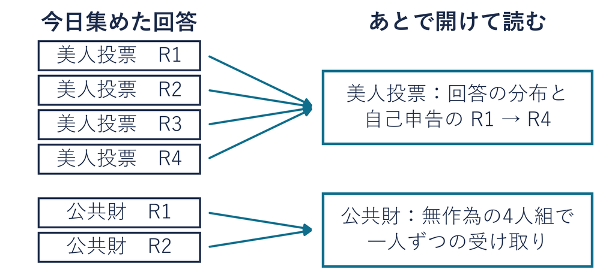

分布も一人ずつの数も、開けるのはあとで

## 予想・観測・モデル

| ことば | 意味 | 今日の例 |
| --- | --- | --- |
| 予想 | 結果を知る前の見込み | 「次は上げる？下げる？」 への心の中の答え |
| 観測 | 実際に記録された値 | フォームに送った6つの数 |
| モデル | 人の選び方をルールとして 書いたもの | 「R1 と同じ数を出す」 というルール |

この授業では、観測とモデルを並べて比べる。予想は、  
その比べ方を決める前の見込み

## シミュレーションとデータの出所

用語：シミュレーション

人の選び方をルールにして、  
計算機で集団の結果を作ること

- **教室**：今日この教室で集めた回答
- **動画**：動画で参加した人の回答（教室と分ける）
- **合成**：計算機で作った練習用のデータ  
  （出所はラベルで分ける）

## 動画の見方

- **動画でも進む**：この授業は、動画を見ながら手を動かして進む回もある
- **⏸ の枚**：その枚で動画を止め、手を動かす
- **答えはフォームへ**：止めた枚で出た問いの答えは、フォームに送る

練習：次の授業までに、動画のページと、  
配布する表のファイルが開けるか試しておく

## まとめ：1行メモを残す

- **6つの回答**：美人投票の R1〜R4 と公共財の R1・R2。あとで開けて読む
- **予想・観測・モデル**：3つを分けて、観測とモデルを比べる
- **データの出所**：教室・動画・合成をラベルで分けて残す

respon（番号 561823449・10月12日 0:00 まで）に1行  
平均を見る前に考えた予想を1つ（ゲーム名・予想・理由）

結果を知る前の選択を、データとして残した